# Risk Factor Analysis

## Outcome Variable

**Outcome Variable:** ever_wasted

## Predictor Variables

**Intervention Variable:** mage

**Adjustment Set:**

unadjusted

## Stratifying Variables

The analysis was stratified on these variable(s):

- agecat
- studyid
- country

## Data Summary

| agecat | studyid | country | mage | ever_wasted | n_cell | n |
| --- | --- | --- | --- | --- | --- | --- |
| 0-24 months | ki0047075b-MAL-ED | BANGLADESH | [20-30) | 0 | 130 | 263 |
| 0-24 months | ki0047075b-MAL-ED | BANGLADESH | [20-30) | 1 | 50 | 263 |
| 0-24 months | ki0047075b-MAL-ED | BANGLADESH | <20 | 0 | 18 | 263 |
| 0-24 months | ki0047075b-MAL-ED | BANGLADESH | <20 | 1 | 19 | 263 |
| 0-24 months | ki0047075b-MAL-ED | BANGLADESH | >=30 | 0 | 28 | 263 |
| 0-24 months | ki0047075b-MAL-ED | BANGLADESH | >=30 | 1 | 18 | 263 |
| 0-24 months | ki0047075b-MAL-ED | BRAZIL | [20-30) | 0 | 127 | 233 |
| 0-24 months | ki0047075b-MAL-ED | BRAZIL | [20-30) | 1 | 12 | 233 |
| 0-24 months | ki0047075b-MAL-ED | BRAZIL | <20 | 0 | 40 | 233 |
| 0-24 months | ki0047075b-MAL-ED | BRAZIL | <20 | 1 | 3 | 233 |
| 0-24 months | ki0047075b-MAL-ED | BRAZIL | >=30 | 0 | 47 | 233 |
| 0-24 months | ki0047075b-MAL-ED | BRAZIL | >=30 | 1 | 4 | 233 |
| 0-24 months | ki0047075b-MAL-ED | INDIA | [20-30) | 0 | 102 | 249 |
| 0-24 months | ki0047075b-MAL-ED | INDIA | [20-30) | 1 | 92 | 249 |
| 0-24 months | ki0047075b-MAL-ED | INDIA | <20 | 0 | 15 | 249 |
| 0-24 months | ki0047075b-MAL-ED | INDIA | <20 | 1 | 19 | 249 |
| 0-24 months | ki0047075b-MAL-ED | INDIA | >=30 | 0 | 15 | 249 |
| 0-24 months | ki0047075b-MAL-ED | INDIA | >=30 | 1 | 6 | 249 |
| 0-24 months | ki0047075b-MAL-ED | NEPAL | [20-30) | 0 | 134 | 240 |
| 0-24 months | ki0047075b-MAL-ED | NEPAL | [20-30) | 1 | 55 | 240 |
| 0-24 months | ki0047075b-MAL-ED | NEPAL | <20 | 0 | 2 | 240 |
| 0-24 months | ki0047075b-MAL-ED | NEPAL | <20 | 1 | 3 | 240 |
| 0-24 months | ki0047075b-MAL-ED | NEPAL | >=30 | 0 | 35 | 240 |
| 0-24 months | ki0047075b-MAL-ED | NEPAL | >=30 | 1 | 11 | 240 |
| 0-24 months | ki0047075b-MAL-ED | PERU | [20-30) | 0 | 140 | 302 |
| 0-24 months | ki0047075b-MAL-ED | PERU | [20-30) | 1 | 13 | 302 |
| 0-24 months | ki0047075b-MAL-ED | PERU | <20 | 0 | 74 | 302 |
| 0-24 months | ki0047075b-MAL-ED | PERU | <20 | 1 | 8 | 302 |
| 0-24 months | ki0047075b-MAL-ED | PERU | >=30 | 0 | 62 | 302 |
| 0-24 months | ki0047075b-MAL-ED | PERU | >=30 | 1 | 5 | 302 |

[output cut: 450 more lines]

The following strata were considered:

- agecat: 0-24 months, studyid: ki0047075b-MAL-ED, country: BANGLADESH
- agecat: 0-24 months, studyid: ki0047075b-MAL-ED, country: BRAZIL
- agecat: 0-24 months, studyid: ki0047075b-MAL-ED, country: INDIA
- agecat: 0-24 months, studyid: ki0047075b-MAL-ED, country: NEPAL
- agecat: 0-24 months, studyid: ki0047075b-MAL-ED, country: PERU
- agecat: 0-24 months, studyid: ki0047075b-MAL-ED, country: SOUTH AFRICA
- agecat: 0-24 months, studyid: ki0047075b-MAL-ED, country: TANZANIA, UNITED REPUBLIC OF
- agecat: 0-24 months, studyid: ki1000108-CMC-V-BCS-2002, country: INDIA
- agecat: 0-24 months, studyid: ki1000108-IRC, country: INDIA
- agecat: 0-24 months, studyid: ki1000109-EE, country: PAKISTAN
- agecat: 0-24 months, studyid: ki1000304b-SAS-CompFeed, country: INDIA
- agecat: 0-24 months, studyid: ki1000304b-SAS-FoodSuppl, country: INDIA
- agecat: 0-24 months, studyid: ki1017093-NIH-Birth, country: BANGLADESH
- agecat: 0-24 months, studyid: ki1017093b-PROVIDE, country: BANGLADESH
- agecat: 0-24 months, studyid: ki1017093c-NIH-Crypto, country: BANGLADESH
- agecat: 0-24 months, studyid: ki1066203-TanzaniaChild2, country: TANZANIA, UNITED REPUBLIC OF
- agecat: 0-24 months, studyid: ki1101329-Keneba, country: GAMBIA
- agecat: 0-24 months, studyid: ki1112895-Guatemala BSC, country: GUATEMALA
- agecat: 0-24 months, studyid: ki1112895-iLiNS-Zinc, country: BURKINA FASO
- agecat: 0-24 months, studyid: ki1113344-GMS-Nepal, country: NEPAL
- agecat: 0-24 months, studyid: ki1119695-PROBIT, country: BELARUS
- agecat: 0-24 months, studyid: ki1126311-ZVITAMBO, country: ZIMBABWE
- agecat: 0-24 months, studyid: ki1135781-COHORTS, country: GUATEMALA
- agecat: 0-24 months, studyid: ki1135781-COHORTS, country: INDIA
- agecat: 0-24 months, studyid: ki1135781-COHORTS, country: PHILIPPINES
- agecat: 0-24 months, studyid: ki1148112-LCNI-5, country: MALAWI
- agecat: 0-24 months, studyid: kiGH5241-JiVitA-3, country: BANGLADESH
- agecat: 0-6 months, studyid: ki0047075b-MAL-ED, country: BANGLADESH
- agecat: 0-6 months, studyid: ki0047075b-MAL-ED, country: BRAZIL
- agecat: 0-6 months, studyid: ki0047075b-MAL-ED, country: INDIA
- agecat: 0-6 months, studyid: ki0047075b-MAL-ED, country: NEPAL
- agecat: 0-6 months, studyid: ki0047075b-MAL-ED, country: PERU
- agecat: 0-6 months, studyid: ki0047075b-MAL-ED, country: SOUTH AFRICA
- agecat: 0-6 months, studyid: ki0047075b-MAL-ED, country: TANZANIA, UNITED REPUBLIC OF
- agecat: 0-6 months, studyid: ki1000108-CMC-V-BCS-2002, country: INDIA
- agecat: 0-6 months, studyid: ki1000108-IRC, country: INDIA
- agecat: 0-6 months, studyid: ki1000109-EE, country: PAKISTAN
- agecat: 0-6 months, studyid: ki1000304b-SAS-CompFeed, country: INDIA
- agecat: 0-6 months, studyid: ki1000304b-SAS-FoodSuppl, country: INDIA
- agecat: 0-6 months, studyid: ki1017093-NIH-Birth, country: BANGLADESH
- agecat: 0-6 months, studyid: ki1017093b-PROVIDE, country: BANGLADESH
- agecat: 0-6 months, studyid: ki1017093c-NIH-Crypto, country: BANGLADESH
- agecat: 0-6 months, studyid: ki1066203-TanzaniaChild2, country: TANZANIA, UNITED REPUBLIC OF
- agecat: 0-6 months, studyid: ki1101329-Keneba, country: GAMBIA
- agecat: 0-6 months, studyid: ki1112895-Guatemala BSC, country: GUATEMALA
- agecat: 0-6 months, studyid: ki1113344-GMS-Nepal, country: NEPAL
- agecat: 0-6 months, studyid: ki1119695-PROBIT, country: BELARUS
- agecat: 0-6 months, studyid: ki1126311-ZVITAMBO, country: ZIMBABWE
- agecat: 0-6 months, studyid: ki1135781-COHORTS, country: GUATEMALA
- agecat: 0-6 months, studyid: ki1135781-COHORTS, country: INDIA
- agecat: 0-6 months, studyid: ki1135781-COHORTS, country: PHILIPPINES
- agecat: 0-6 months, studyid: ki1148112-LCNI-5, country: MALAWI
- agecat: 0-6 months, studyid: kiGH5241-JiVitA-3, country: BANGLADESH
- agecat: 6-24 months, studyid: ki0047075b-MAL-ED, country: BANGLADESH
- agecat: 6-24 months, studyid: ki0047075b-MAL-ED, country: BRAZIL
- agecat: 6-24 months, studyid: ki0047075b-MAL-ED, country: INDIA
- agecat: 6-24 months, studyid: ki0047075b-MAL-ED, country: NEPAL
- agecat: 6-24 months, studyid: ki0047075b-MAL-ED, country: PERU
- agecat: 6-24 months, studyid: ki0047075b-MAL-ED, country: SOUTH AFRICA
- agecat: 6-24 months, studyid: ki0047075b-MAL-ED, country: TANZANIA, UNITED REPUBLIC OF
- agecat: 6-24 months, studyid: ki1000108-CMC-V-BCS-2002, country: INDIA
- agecat: 6-24 months, studyid: ki1000108-IRC, country: INDIA
- agecat: 6-24 months, studyid: ki1000109-EE, country: PAKISTAN
- agecat: 6-24 months, studyid: ki1000304b-SAS-CompFeed, country: INDIA
- agecat: 6-24 months, studyid: ki1000304b-SAS-FoodSuppl, country: INDIA
- agecat: 6-24 months, studyid: ki1017093-NIH-Birth, country: BANGLADESH
- agecat: 6-24 months, studyid: ki1017093b-PROVIDE, country: BANGLADESH
- agecat: 6-24 months, studyid: ki1017093c-NIH-Crypto, country: BANGLADESH
- agecat: 6-24 months, studyid: ki1066203-TanzaniaChild2, country: TANZANIA, UNITED REPUBLIC OF
- agecat: 6-24 months, studyid: ki1101329-Keneba, country: GAMBIA
- agecat: 6-24 months, studyid: ki1112895-Guatemala BSC, country: GUATEMALA
- agecat: 6-24 months, studyid: ki1112895-iLiNS-Zinc, country: BURKINA FASO
- agecat: 6-24 months, studyid: ki1113344-GMS-Nepal, country: NEPAL
- agecat: 6-24 months, studyid: ki1119695-PROBIT, country: BELARUS
- agecat: 6-24 months, studyid: ki1126311-ZVITAMBO, country: ZIMBABWE
- agecat: 6-24 months, studyid: ki1135781-COHORTS, country: GUATEMALA
- agecat: 6-24 months, studyid: ki1135781-COHORTS, country: INDIA
- agecat: 6-24 months, studyid: ki1135781-COHORTS, country: PHILIPPINES
- agecat: 6-24 months, studyid: ki1148112-LCNI-5, country: MALAWI
- agecat: 6-24 months, studyid: kiGH5241-JiVitA-3, country: BANGLADESH

### Dropped Strata

Some strata were dropped due to rare outcomes:

- agecat: 0-24 months, studyid: ki0047075b-MAL-ED, country: BRAZIL
- agecat: 0-24 months, studyid: ki0047075b-MAL-ED, country: NEPAL
- agecat: 0-24 months, studyid: ki0047075b-MAL-ED, country: TANZANIA, UNITED REPUBLIC OF
- agecat: 0-24 months, studyid: ki1000109-EE, country: PAKISTAN
- agecat: 0-24 months, studyid: ki1000304b-SAS-FoodSuppl, country: INDIA
- agecat: 0-6 months, studyid: ki0047075b-MAL-ED, country: BRAZIL
- agecat: 0-6 months, studyid: ki0047075b-MAL-ED, country: NEPAL
- agecat: 0-6 months, studyid: ki0047075b-MAL-ED, country: PERU
- agecat: 0-6 months, studyid: ki0047075b-MAL-ED, country: TANZANIA, UNITED REPUBLIC OF
- agecat: 0-6 months, studyid: ki1000109-EE, country: PAKISTAN
- agecat: 0-6 months, studyid: ki1000304b-SAS-FoodSuppl, country: INDIA
- agecat: 0-6 months, studyid: ki1112895-Guatemala BSC, country: GUATEMALA
- agecat: 0-6 months, studyid: ki1148112-LCNI-5, country: MALAWI
- agecat: 6-24 months, studyid: ki0047075b-MAL-ED, country: BRAZIL
- agecat: 6-24 months, studyid: ki0047075b-MAL-ED, country: INDIA
- agecat: 6-24 months, studyid: ki0047075b-MAL-ED, country: NEPAL
- agecat: 6-24 months, studyid: ki0047075b-MAL-ED, country: PERU
- agecat: 6-24 months, studyid: ki0047075b-MAL-ED, country: SOUTH AFRICA
- agecat: 6-24 months, studyid: ki0047075b-MAL-ED, country: TANZANIA, UNITED REPUBLIC OF
- agecat: 6-24 months, studyid: ki1000109-EE, country: PAKISTAN
- agecat: 6-24 months, studyid: ki1000304b-SAS-FoodSuppl, country: INDIA
- agecat: 6-24 months, studyid: ki1112895-Guatemala BSC, country: GUATEMALA

## Methods Detail

We’re interested in the causal parameters $E[Y_a]$ for all values of $a \in \mathcal{A}$. These parameters represent the mean outcome if, possibly contrary to fact, we intervened to set all units to have $A=a$. Under the randomization and positivity assumptions, these are identified by the statistical parameters $\psi_a=E_W[E_{Y|A,W}(Y|A=a,W)]$. In addition, we’re interested in the mean of $Y$, $E[Y]$ under no intervention (the observed mean). We will estimate these parameters by using SuperLearner to fit the relevant likelihood factors – $E_{Y|A,W}(Y|A=a,W)$ and $p(A=a|W)$, and then updating our likelihood fit using a joint TMLE.

For unadjusted analyses ($W=\{\}$), initial likelihoods were estimated using Lrnr_glm to estimate the simple $E(Y|A)$ and Lrnr_mean to estimate $p(A)$. For adjusted analyses, a small library containing Lrnr_glmnet, Lrnr_xgboost, and Lrnr_mean was used.

Having estimated these parameters, we will then use the delta method to estimate relative risks and attributable risks relative to a prespecified baseline level of $A$.

# Results Detail

## Results Plots

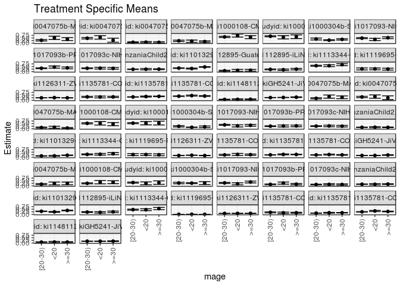

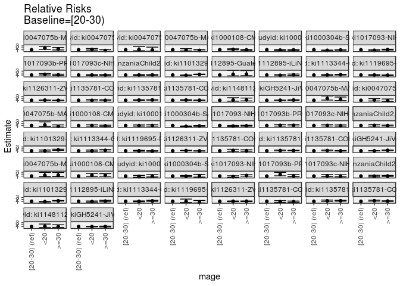

[figure not shown]

[figure not shown]

## Results Table

### Parameter: TSM

| agecat | studyid | country | intervention_level | baseline_level | estimate | ci_lower | ci_upper |
| --- | --- | --- | --- | --- | --- | --- | --- |
| 0-24 months | ki0047075b-MAL-ED | BANGLADESH | [20-30) | NA | 0.2777778 | 0.2122201 | 0.3433354 |
| 0-24 months | ki0047075b-MAL-ED | BANGLADESH | <20 | NA | 0.5135135 | 0.3521573 | 0.6748698 |
| 0-24 months | ki0047075b-MAL-ED | BANGLADESH | >=30 | NA | 0.3913043 | 0.2500005 | 0.5326081 |
| 0-24 months | ki0047075b-MAL-ED | INDIA | [20-30) | NA | 0.4742268 | 0.4038202 | 0.5446334 |
| 0-24 months | ki0047075b-MAL-ED | INDIA | <20 | NA | 0.5588235 | 0.3915890 | 0.7260581 |
| 0-24 months | ki0047075b-MAL-ED | INDIA | >=30 | NA | 0.2857143 | 0.0921103 | 0.4793182 |
| 0-24 months | ki0047075b-MAL-ED | PERU | [20-30) | NA | 0.0849673 | 0.0407119 | 0.1292228 |
| 0-24 months | ki0047075b-MAL-ED | PERU | <20 | NA | 0.0975610 | 0.0332317 | 0.1618902 |
| 0-24 months | ki0047075b-MAL-ED | PERU | >=30 | NA | 0.0746269 | 0.0115984 | 0.1376554 |
| 0-24 months | ki0047075b-MAL-ED | SOUTH AFRICA | [20-30) | NA | 0.2264151 | 0.1612593 | 0.2915709 |
| 0-24 months | ki0047075b-MAL-ED | SOUTH AFRICA | <20 | NA | 0.1875000 | 0.0769046 | 0.2980954 |
| 0-24 months | ki0047075b-MAL-ED | SOUTH AFRICA | >=30 | NA | 0.1523810 | 0.0835290 | 0.2212329 |
| 0-24 months | ki1000108-CMC-V-BCS-2002 | INDIA | [20-30) | NA | 0.6047297 | 0.5489582 | 0.6605013 |
| 0-24 months | ki1000108-CMC-V-BCS-2002 | INDIA | <20 | NA | 0.7352941 | 0.5868018 | 0.8837864 |
| 0-24 months | ki1000108-CMC-V-BCS-2002 | INDIA | >=30 | NA | 0.5813953 | 0.4337450 | 0.7290457 |
| 0-24 months | ki1000108-IRC | INDIA | [20-30) | NA | 0.6686047 | 0.6188015 | 0.7184078 |
| 0-24 months | ki1000108-IRC | INDIA | <20 | NA | 0.5675676 | 0.4077423 | 0.7273928 |
| 0-24 months | ki1000108-IRC | INDIA | >=30 | NA | 0.6206897 | 0.4438767 | 0.7975026 |
| 0-24 months | ki1000304b-SAS-CompFeed | INDIA | [20-30) | NA | 0.4035088 | 0.3100107 | 0.4970068 |
| 0-24 months | ki1000304b-SAS-CompFeed | INDIA | <20 | NA | 0.2898551 | 0.2497185 | 0.3299916 |
| 0-24 months | ki1000304b-SAS-CompFeed | INDIA | >=30 | NA | 0.3653846 | 0.2996752 | 0.4310940 |
| 0-24 months | ki1017093-NIH-Birth | BANGLADESH | [20-30) | NA | 0.4844125 | 0.4364073 | 0.5324177 |
| 0-24 months | ki1017093-NIH-Birth | BANGLADESH | <20 | NA | 0.3561644 | 0.2462261 | 0.4661026 |
| 0-24 months | ki1017093-NIH-Birth | BANGLADESH | >=30 | NA | 0.5227273 | 0.4374504 | 0.6080042 |
| 0-24 months | ki1017093b-PROVIDE | BANGLADESH | [20-30) | NA | 0.3306288 | 0.2890723 | 0.3721853 |
| 0-24 months | ki1017093b-PROVIDE | BANGLADESH | <20 | NA | 0.4470588 | 0.3412868 | 0.5528309 |
| 0-24 months | ki1017093b-PROVIDE | BANGLADESH | >=30 | NA | 0.3688525 | 0.2831742 | 0.4545307 |
| 0-24 months | ki1017093c-NIH-Crypto | BANGLADESH | [20-30) | NA | 0.3319838 | 0.2904288 | 0.3735388 |
| 0-24 months | ki1017093c-NIH-Crypto | BANGLADESH | <20 | NA | 0.3382353 | 0.2586695 | 0.4178011 |
| 0-24 months | ki1017093c-NIH-Crypto | BANGLADESH | >=30 | NA | 0.3203125 | 0.2394269 | 0.4011981 |

[output cut: 144 more lines]

### Parameter: E(Y)

| agecat | studyid | country | intervention_level | baseline_level | estimate | ci_lower | ci_upper |
| --- | --- | --- | --- | --- | --- | --- | --- |
| 0-24 months | ki0047075b-MAL-ED | BANGLADESH | NA | NA | 0.3307985 | 0.2738270 | 0.3877700 |
| 0-24 months | ki0047075b-MAL-ED | INDIA | NA | NA | 0.4698795 | 0.4077636 | 0.5319954 |
| 0-24 months | ki0047075b-MAL-ED | PERU | NA | NA | 0.0860927 | 0.0544044 | 0.1177810 |
| 0-24 months | ki0047075b-MAL-ED | SOUTH AFRICA | NA | NA | 0.1955128 | 0.1514355 | 0.2395901 |
| 0-24 months | ki1000108-CMC-V-BCS-2002 | INDIA | NA | NA | 0.6139410 | 0.5644682 | 0.6634139 |
| 0-24 months | ki1000108-IRC | INDIA | NA | NA | 0.6560976 | 0.6100625 | 0.7021326 |
| 0-24 months | ki1000304b-SAS-CompFeed | INDIA | NA | NA | 0.3822894 | 0.3008363 | 0.4637425 |
| 0-24 months | ki1017093-NIH-Birth | BANGLADESH | NA | NA | 0.4774920 | 0.4382065 | 0.5167774 |
| 0-24 months | ki1017093b-PROVIDE | BANGLADESH | NA | NA | 0.3514286 | 0.3160364 | 0.3868207 |
| 0-24 months | ki1017093c-NIH-Crypto | BANGLADESH | NA | NA | 0.3311346 | 0.2976093 | 0.3646598 |
| 0-24 months | ki1066203-TanzaniaChild2 | TANZANIA, UNITED REPUBLIC OF | NA | NA | 0.2369529 | 0.2198518 | 0.2540539 |
| 0-24 months | ki1101329-Keneba | GAMBIA | NA | NA | 0.3789731 | 0.3611996 | 0.3967466 |
| 0-24 months | ki1112895-Guatemala BSC | GUATEMALA | NA | NA | 0.1067616 | 0.0705906 | 0.1429325 |
| 0-24 months | ki1112895-iLiNS-Zinc | BURKINA FASO | NA | NA | 0.2259307 | 0.1907517 | 0.2611097 |
| 0-24 months | ki1113344-GMS-Nepal | NEPAL | NA | NA | 0.5913621 | 0.5520608 | 0.6306634 |
| 0-24 months | ki1119695-PROBIT | BELARUS | NA | NA | 0.2655346 | 0.1719990 | 0.3590703 |
| 0-24 months | ki1126311-ZVITAMBO | ZIMBABWE | NA | NA | 0.2345874 | 0.2275431 | 0.2416318 |
| 0-24 months | ki1135781-COHORTS | GUATEMALA | NA | NA | 0.3216463 | 0.2858742 | 0.3574185 |
| 0-24 months | ki1135781-COHORTS | INDIA | NA | NA | 0.3359095 | 0.3231988 | 0.3486203 |
| 0-24 months | ki1135781-COHORTS | PHILIPPINES | NA | NA | 0.4036125 | 0.3861835 | 0.4210415 |
| 0-24 months | ki1148112-LCNI-5 | MALAWI | NA | NA | 0.0805970 | 0.0599695 | 0.1012246 |
| 0-24 months | kiGH5241-JiVitA-3 | BANGLADESH | NA | NA | 0.2643902 | 0.2553053 | 0.2734752 |
| 0-6 months | ki0047075b-MAL-ED | BANGLADESH | NA | NA | 0.2243346 | 0.1738240 | 0.2748452 |
| 0-6 months | ki0047075b-MAL-ED | INDIA | NA | NA | 0.3132530 | 0.2555274 | 0.3709786 |
| 0-6 months | ki0047075b-MAL-ED | SOUTH AFRICA | NA | NA | 0.1025641 | 0.0688457 | 0.1362825 |
| 0-6 months | ki1000108-CMC-V-BCS-2002 | INDIA | NA | NA | 0.5190217 | 0.4679041 | 0.5701394 |
| 0-6 months | ki1000108-IRC | INDIA | NA | NA | 0.5439024 | 0.4956326 | 0.5921723 |
| 0-6 months | ki1000304b-SAS-CompFeed | INDIA | NA | NA | 0.2207792 | 0.1636864 | 0.2778721 |
| 0-6 months | ki1017093-NIH-Birth | BANGLADESH | NA | NA | 0.3580645 | 0.3202961 | 0.3958330 |
| 0-6 months | ki1017093b-PROVIDE | BANGLADESH | NA | NA | 0.2585714 | 0.2261125 | 0.2910304 |
| 0-6 months | ki1017093c-NIH-Crypto | BANGLADESH | NA | NA | 0.2585752 | 0.2273844 | 0.2897660 |
| 0-6 months | ki1066203-TanzaniaChild2 | TANZANIA, UNITED REPUBLIC OF | NA | NA | 0.1397306 | 0.1257869 | 0.1536744 |
| 0-6 months | ki1101329-Keneba | GAMBIA | NA | NA | 0.1598344 | 0.1452161 | 0.1744527 |
| 0-6 months | ki1113344-GMS-Nepal | NEPAL | NA | NA | 0.2956811 | 0.2591967 | 0.3321655 |
| 0-6 months | ki1119695-PROBIT | BELARUS | NA | NA | 0.2599065 | 0.1654090 | 0.3544039 |
| 0-6 months | ki1126311-ZVITAMBO | ZIMBABWE | NA | NA | 0.1808241 | 0.1744046 | 0.1872436 |
| 0-6 months | ki1135781-COHORTS | GUATEMALA | NA | NA | 0.2485323 | 0.2110255 | 0.2860391 |
| 0-6 months | ki1135781-COHORTS | INDIA | NA | NA | 0.2500980 | 0.2382136 | 0.2619824 |
| 0-6 months | ki1135781-COHORTS | PHILIPPINES | NA | NA | 0.2355453 | 0.2204685 | 0.2506222 |
| 0-6 months | kiGH5241-JiVitA-3 | BANGLADESH | NA | NA | 0.1823591 | 0.1743561 | 0.1903622 |
| 6-24 months | ki0047075b-MAL-ED | BANGLADESH | NA | NA | 0.1833333 | 0.1342773 | 0.2323893 |
| 6-24 months | ki1000108-CMC-V-BCS-2002 | INDIA | NA | NA | 0.2654155 | 0.2205451 | 0.3102860 |
| 6-24 months | ki1000108-IRC | INDIA | NA | NA | 0.3097561 | 0.2649438 | 0.3545684 |
| 6-24 months | ki1000304b-SAS-CompFeed | INDIA | NA | NA | 0.2708333 | 0.2169112 | 0.3247555 |
| 6-24 months | ki1017093-NIH-Birth | BANGLADESH | NA | NA | 0.2931354 | 0.2546710 | 0.3315999 |
| 6-24 months | ki1017093b-PROVIDE | BANGLADESH | NA | NA | 0.1609756 | 0.1319065 | 0.1900447 |
| 6-24 months | ki1017093c-NIH-Crypto | BANGLADESH | NA | NA | 0.1315068 | 0.1069744 | 0.1560393 |
| 6-24 months | ki1066203-TanzaniaChild2 | TANZANIA, UNITED REPUBLIC OF | NA | NA | 0.1607589 | 0.1446692 | 0.1768485 |
| 6-24 months | ki1101329-Keneba | GAMBIA | NA | NA | 0.3205653 | 0.3029225 | 0.3382080 |
| 6-24 months | ki1112895-iLiNS-Zinc | BURKINA FASO | NA | NA | 0.2259307 | 0.1907517 | 0.2611097 |
| 6-24 months | ki1113344-GMS-Nepal | NEPAL | NA | NA | 0.4728814 | 0.4325613 | 0.5132014 |
| 6-24 months | ki1119695-PROBIT | BELARUS | NA | NA | 0.0082759 | 0.0065972 | 0.0099545 |
| 6-24 months | ki1126311-ZVITAMBO | ZIMBABWE | NA | NA | 0.0940195 | 0.0884810 | 0.0995580 |
| 6-24 months | ki1135781-COHORTS | GUATEMALA | NA | NA | 0.1731092 | 0.1426836 | 0.2035348 |
| 6-24 months | ki1135781-COHORTS | INDIA | NA | NA | 0.1317329 | 0.1223171 | 0.1411487 |
| 6-24 months | ki1135781-COHORTS | PHILIPPINES | NA | NA | 0.2666429 | 0.2502871 | 0.2829988 |
| 6-24 months | ki1148112-LCNI-5 | MALAWI | NA | NA | 0.0789074 | 0.0583085 | 0.0995064 |
| 6-24 months | kiGH5241-JiVitA-3 | BANGLADESH | NA | NA | 0.1652052 | 0.1560335 | 0.1743768 |

### Parameter: RR

| agecat | studyid | country | intervention_level | baseline_level | estimate | ci_lower | ci_upper |
| --- | --- | --- | --- | --- | --- | --- | --- |
| 0-24 months | ki0047075b-MAL-ED | BANGLADESH | [20-30) | [20-30) | 1.0000000 | 1.0000000 | 1.0000000 |
| 0-24 months | ki0047075b-MAL-ED | BANGLADESH | <20 | [20-30) | 1.8486486 | 1.2479152 | 2.7385690 |
| 0-24 months | ki0047075b-MAL-ED | BANGLADESH | >=30 | [20-30) | 1.4086957 | 0.9150939 | 2.1685462 |
| 0-24 months | ki0047075b-MAL-ED | INDIA | [20-30) | [20-30) | 1.0000000 | 1.0000000 | 1.0000000 |
| 0-24 months | ki0047075b-MAL-ED | INDIA | <20 | [20-30) | 1.1783887 | 0.8437344 | 1.6457786 |
| 0-24 months | ki0047075b-MAL-ED | INDIA | >=30 | [20-30) | 0.6024845 | 0.3010794 | 1.2056205 |
| 0-24 months | ki0047075b-MAL-ED | PERU | [20-30) | [20-30) | 1.0000000 | 1.0000000 | 1.0000000 |
| 0-24 months | ki0047075b-MAL-ED | PERU | <20 | [20-30) | 1.1482176 | 0.4955612 | 2.6604256 |
| 0-24 months | ki0047075b-MAL-ED | PERU | >=30 | [20-30) | 0.8783008 | 0.3256151 | 2.3690927 |
| 0-24 months | ki0047075b-MAL-ED | SOUTH AFRICA | [20-30) | [20-30) | 1.0000000 | 1.0000000 | 1.0000000 |
| 0-24 months | ki0047075b-MAL-ED | SOUTH AFRICA | <20 | [20-30) | 0.8281250 | 0.4296053 | 1.5963280 |
| 0-24 months | ki0047075b-MAL-ED | SOUTH AFRICA | >=30 | [20-30) | 0.6730159 | 0.3938896 | 1.1499425 |
| 0-24 months | ki1000108-CMC-V-BCS-2002 | INDIA | [20-30) | [20-30) | 1.0000000 | 1.0000000 | 1.0000000 |
| 0-24 months | ki1000108-CMC-V-BCS-2002 | INDIA | <20 | [20-30) | 1.2159054 | 0.9738259 | 1.5181623 |
| 0-24 months | ki1000108-CMC-V-BCS-2002 | INDIA | >=30 | [20-30) | 0.9614135 | 0.7337867 | 1.2596521 |
| 0-24 months | ki1000108-IRC | INDIA | [20-30) | [20-30) | 1.0000000 | 1.0000000 | 1.0000000 |
| 0-24 months | ki1000108-IRC | INDIA | <20 | [20-30) | 0.8488837 | 0.6343748 | 1.1359270 |
| 0-24 months | ki1000108-IRC | INDIA | >=30 | [20-30) | 0.9283358 | 0.6915604 | 1.2461781 |
| 0-24 months | ki1000304b-SAS-CompFeed | INDIA | [20-30) | [20-30) | 1.0000000 | 1.0000000 | 1.0000000 |
| 0-24 months | ki1000304b-SAS-CompFeed | INDIA | <20 | [20-30) | 0.7183365 | 0.6015961 | 0.8577305 |
| 0-24 months | ki1000304b-SAS-CompFeed | INDIA | >=30 | [20-30) | 0.9055184 | 0.8015343 | 1.0229925 |
| 0-24 months | ki1017093-NIH-Birth | BANGLADESH | [20-30) | [20-30) | 1.0000000 | 1.0000000 | 1.0000000 |
| 0-24 months | ki1017093-NIH-Birth | BANGLADESH | <20 | [20-30) | 0.7352502 | 0.5316685 | 1.0167857 |
| 0-24 months | ki1017093-NIH-Birth | BANGLADESH | >=30 | [20-30) | 1.0790954 | 0.8915835 | 1.3060436 |
| 0-24 months | ki1017093b-PROVIDE | BANGLADESH | [20-30) | [20-30) | 1.0000000 | 1.0000000 | 1.0000000 |
| 0-24 months | ki1017093b-PROVIDE | BANGLADESH | <20 | [20-30) | 1.3521472 | 1.0343622 | 1.7675647 |
| 0-24 months | ki1017093b-PROVIDE | BANGLADESH | >=30 | [20-30) | 1.1156090 | 0.8566653 | 1.4528234 |
| 0-24 months | ki1017093c-NIH-Crypto | BANGLADESH | [20-30) | [20-30) | 1.0000000 | 1.0000000 | 1.0000000 |
| 0-24 months | ki1017093c-NIH-Crypto | BANGLADESH | <20 | [20-30) | 1.0188307 | 0.7805067 | 1.3299257 |
| 0-24 months | ki1017093c-NIH-Crypto | BANGLADESH | >=30 | [20-30) | 0.9648438 | 0.7278714 | 1.2789670 |

[output cut: 144 more lines]

### Parameter: PAR

| agecat | studyid | country | intervention_level | baseline_level | estimate | ci_lower | ci_upper |
| --- | --- | --- | --- | --- | --- | --- | --- |
| 0-24 months | ki0047075b-MAL-ED | BANGLADESH | [20-30) | NA | 0.0530207 | 0.0122699 | 0.0937715 |
| 0-24 months | ki0047075b-MAL-ED | INDIA | [20-30) | NA | -0.0043473 | -0.0373802 | 0.0286857 |
| 0-24 months | ki0047075b-MAL-ED | PERU | [20-30) | NA | 0.0011254 | -0.0301509 | 0.0324017 |
| 0-24 months | ki0047075b-MAL-ED | SOUTH AFRICA | [20-30) | NA | -0.0309023 | -0.0740435 | 0.0122390 |
| 0-24 months | ki1000108-CMC-V-BCS-2002 | INDIA | [20-30) | NA | 0.0092113 | -0.0157148 | 0.0341373 |
| 0-24 months | ki1000108-IRC | INDIA | [20-30) | NA | -0.0125071 | -0.0334217 | 0.0084075 |
| 0-24 months | ki1000304b-SAS-CompFeed | INDIA | [20-30) | NA | -0.0212194 | -0.0382678 | -0.0041709 |
| 0-24 months | ki1017093-NIH-Birth | BANGLADESH | [20-30) | NA | -0.0069205 | -0.0344503 | 0.0206093 |
| 0-24 months | ki1017093b-PROVIDE | BANGLADESH | [20-30) | NA | 0.0207998 | -0.0025888 | 0.0441883 |
| 0-24 months | ki1017093c-NIH-Crypto | BANGLADESH | [20-30) | NA | -0.0008492 | -0.0253436 | 0.0236451 |
| 0-24 months | ki1066203-TanzaniaChild2 | TANZANIA, UNITED REPUBLIC OF | [20-30) | NA | 0.0033437 | -0.0089546 | 0.0156420 |
| 0-24 months | ki1101329-Keneba | GAMBIA | [20-30) | NA | 0.0345518 | 0.0169147 | 0.0521888 |
| 0-24 months | ki1112895-Guatemala BSC | GUATEMALA | [20-30) | NA | 0.0153330 | -0.0139754 | 0.0446414 |
| 0-24 months | ki1112895-iLiNS-Zinc | BURKINA FASO | [20-30) | NA | 0.0034588 | -0.0176790 | 0.0245966 |
| 0-24 months | ki1113344-GMS-Nepal | NEPAL | [20-30) | NA | 0.0166199 | -0.0124318 | 0.0456716 |
| 0-24 months | ki1119695-PROBIT | BELARUS | [20-30) | NA | -0.0035321 | -0.0155265 | 0.0084624 |
| 0-24 months | ki1126311-ZVITAMBO | ZIMBABWE | [20-30) | NA | 0.0033655 | -0.0015781 | 0.0083092 |
| 0-24 months | ki1135781-COHORTS | GUATEMALA | [20-30) | NA | -0.0030290 | -0.0410638 | 0.0350059 |
| 0-24 months | ki1135781-COHORTS | INDIA | [20-30) | NA | 0.0167547 | 0.0078713 | 0.0256381 |
| 0-24 months | ki1135781-COHORTS | PHILIPPINES | [20-30) | NA | 0.0113048 | -0.0030274 | 0.0256370 |
| 0-24 months | ki1148112-LCNI-5 | MALAWI | [20-30) | NA | 0.0064212 | -0.0126225 | 0.0254649 |
| 0-24 months | kiGH5241-JiVitA-3 | BANGLADESH | [20-30) | NA | 0.0086473 | 0.0007830 | 0.0165115 |
| 0-6 months | ki0047075b-MAL-ED | BANGLADESH | [20-30) | NA | 0.0410013 | 0.0040102 | 0.0779923 |
| 0-6 months | ki0047075b-MAL-ED | INDIA | [20-30) | NA | -0.0011800 | -0.0318367 | 0.0294767 |
| 0-6 months | ki0047075b-MAL-ED | SOUTH AFRICA | [20-30) | NA | -0.0106434 | -0.0436607 | 0.0223738 |
| 0-6 months | ki1000108-CMC-V-BCS-2002 | INDIA | [20-30) | NA | -0.0083755 | -0.0345119 | 0.0177608 |
| 0-6 months | ki1000108-IRC | INDIA | [20-30) | NA | 0.0002978 | -0.0208406 | 0.0214362 |
| 0-6 months | ki1000304b-SAS-CompFeed | INDIA | [20-30) | NA | -0.0196900 | -0.0293592 | -0.0100208 |
| 0-6 months | ki1017093-NIH-Birth | BANGLADESH | [20-30) | NA | -0.0217432 | -0.0478485 | 0.0043621 |
| 0-6 months | ki1017093b-PROVIDE | BANGLADESH | [20-30) | NA | 0.0070501 | -0.0142428 | 0.0283430 |
| 0-6 months | ki1017093c-NIH-Crypto | BANGLADESH | [20-30) | NA | 0.0014902 | -0.0213488 | 0.0243292 |
| 0-6 months | ki1066203-TanzaniaChild2 | TANZANIA, UNITED REPUBLIC OF | [20-30) | NA | 0.0003290 | -0.0096617 | 0.0103197 |
| 0-6 months | ki1101329-Keneba | GAMBIA | [20-30) | NA | 0.0260436 | 0.0109830 | 0.0411043 |
| 0-6 months | ki1113344-GMS-Nepal | NEPAL | [20-30) | NA | 0.0121759 | -0.0151893 | 0.0395412 |
| 0-6 months | ki1119695-PROBIT | BELARUS | [20-30) | NA | -0.0030179 | -0.0148282 | 0.0087923 |
| 0-6 months | ki1126311-ZVITAMBO | ZIMBABWE | [20-30) | NA | 0.0021758 | -0.0023222 | 0.0066738 |
| 0-6 months | ki1135781-COHORTS | GUATEMALA | [20-30) | NA | 0.0142227 | -0.0256941 | 0.0541394 |
| 0-6 months | ki1135781-COHORTS | INDIA | [20-30) | NA | 0.0117964 | 0.0034718 | 0.0201210 |
| 0-6 months | ki1135781-COHORTS | PHILIPPINES | [20-30) | NA | 0.0051990 | -0.0072198 | 0.0176178 |
| 0-6 months | kiGH5241-JiVitA-3 | BANGLADESH | [20-30) | NA | 0.0052725 | -0.0018842 | 0.0124292 |
| 6-24 months | ki0047075b-MAL-ED | BANGLADESH | [20-30) | NA | 0.0238241 | -0.0118070 | 0.0594553 |
| 6-24 months | ki1000108-CMC-V-BCS-2002 | INDIA | [20-30) | NA | 0.0221723 | -0.0024646 | 0.0468093 |
| 6-24 months | ki1000108-IRC | INDIA | [20-30) | NA | -0.0071044 | -0.0262133 | 0.0120045 |
| 6-24 months | ki1000304b-SAS-CompFeed | INDIA | [20-30) | NA | -0.0024586 | -0.0315740 | 0.0266568 |
| 6-24 months | ki1017093-NIH-Birth | BANGLADESH | [20-30) | NA | 0.0090129 | -0.0184713 | 0.0364971 |
| 6-24 months | ki1017093b-PROVIDE | BANGLADESH | [20-30) | NA | 0.0161480 | -0.0036200 | 0.0359160 |
| 6-24 months | ki1017093c-NIH-Crypto | BANGLADESH | [20-30) | NA | 0.0028149 | -0.0153536 | 0.0209833 |
| 6-24 months | ki1066203-TanzaniaChild2 | TANZANIA, UNITED REPUBLIC OF | [20-30) | NA | 0.0023809 | -0.0094221 | 0.0141839 |
| 6-24 months | ki1101329-Keneba | GAMBIA | [20-30) | NA | 0.0225817 | 0.0048695 | 0.0402939 |
| 6-24 months | ki1112895-iLiNS-Zinc | BURKINA FASO | [20-30) | NA | 0.0034588 | -0.0176790 | 0.0245966 |
| 6-24 months | ki1113344-GMS-Nepal | NEPAL | [20-30) | NA | 0.0147662 | -0.0150370 | 0.0445693 |
| 6-24 months | ki1119695-PROBIT | BELARUS | [20-30) | NA | -0.0007755 | -0.0019402 | 0.0003892 |
| 6-24 months | ki1126311-ZVITAMBO | ZIMBABWE | [20-30) | NA | 0.0010649 | -0.0028721 | 0.0050019 |
| 6-24 months | ki1135781-COHORTS | GUATEMALA | [20-30) | NA | -0.0219262 | -0.0541338 | 0.0102814 |
| 6-24 months | ki1135781-COHORTS | INDIA | [20-30) | NA | 0.0113763 | 0.0046369 | 0.0181156 |
| 6-24 months | ki1135781-COHORTS | PHILIPPINES | [20-30) | NA | 0.0191833 | 0.0055547 | 0.0328119 |
| 6-24 months | ki1148112-LCNI-5 | MALAWI | [20-30) | NA | 0.0032772 | -0.0157344 | 0.0222887 |
| 6-24 months | kiGH5241-JiVitA-3 | BANGLADESH | [20-30) | NA | 0.0000986 | -0.0087062 | 0.0089034 |

### Parameter: PAF

| agecat | studyid | country | intervention_level | baseline_level | estimate | ci_lower | ci_upper |
| --- | --- | --- | --- | --- | --- | --- | --- |
| 0-24 months | ki0047075b-MAL-ED | BANGLADESH | [20-30) | NA | 0.1602810 | 0.0282063 | 0.2744056 |
| 0-24 months | ki0047075b-MAL-ED | INDIA | [20-30) | NA | -0.0092519 | -0.0820681 | 0.0586642 |
| 0-24 months | ki0047075b-MAL-ED | PERU | [20-30) | NA | 0.0130719 | -0.4260578 | 0.3169792 |
| 0-24 months | ki0047075b-MAL-ED | SOUTH AFRICA | [20-30) | NA | -0.1580575 | -0.3996127 | 0.0418083 |
| 0-24 months | ki1000108-CMC-V-BCS-2002 | INDIA | [20-30) | NA | 0.0150035 | -0.0264849 | 0.0548151 |
| 0-24 months | ki1000108-IRC | INDIA | [20-30) | NA | -0.0190629 | -0.0515274 | 0.0123994 |
| 0-24 months | ki1000304b-SAS-CompFeed | INDIA | [20-30) | NA | -0.0555060 | -0.0941258 | -0.0182494 |
| 0-24 months | ki1017093-NIH-Birth | BANGLADESH | [20-30) | NA | -0.0144935 | -0.0738294 | 0.0415638 |
| 0-24 months | ki1017093b-PROVIDE | BANGLADESH | [20-30) | NA | 0.0591863 | -0.0097826 | 0.1234446 |
| 0-24 months | ki1017093c-NIH-Crypto | BANGLADESH | [20-30) | NA | -0.0025646 | -0.0793328 | 0.0687434 |
| 0-24 months | ki1066203-TanzaniaChild2 | TANZANIA, UNITED REPUBLIC OF | [20-30) | NA | 0.0141112 | -0.0391772 | 0.0646671 |
| 0-24 months | ki1101329-Keneba | GAMBIA | [20-30) | NA | 0.0911721 | 0.0433982 | 0.1365600 |
| 0-24 months | ki1112895-Guatemala BSC | GUATEMALA | [20-30) | NA | 0.1436190 | -0.1752619 | 0.3759788 |
| 0-24 months | ki1112895-iLiNS-Zinc | BURKINA FASO | [20-30) | NA | 0.0153090 | -0.0826141 | 0.1043749 |
| 0-24 months | ki1113344-GMS-Nepal | NEPAL | [20-30) | NA | 0.0281044 | -0.0223528 | 0.0760713 |
| 0-24 months | ki1119695-PROBIT | BELARUS | [20-30) | NA | -0.0133017 | -0.0579849 | 0.0294943 |
| 0-24 months | ki1126311-ZVITAMBO | ZIMBABWE | [20-30) | NA | 0.0143466 | -0.0069523 | 0.0351950 |
| 0-24 months | ki1135781-COHORTS | GUATEMALA | [20-30) | NA | -0.0094171 | -0.1348723 | 0.1021696 |
| 0-24 months | ki1135781-COHORTS | INDIA | [20-30) | NA | 0.0498785 | 0.0230639 | 0.0759571 |
| 0-24 months | ki1135781-COHORTS | PHILIPPINES | [20-30) | NA | 0.0280090 | -0.0081642 | 0.0628843 |
| 0-24 months | ki1148112-LCNI-5 | MALAWI | [20-30) | NA | 0.0796703 | -0.1887603 | 0.2874874 |
| 0-24 months | kiGH5241-JiVitA-3 | BANGLADESH | [20-30) | NA | 0.0327065 | 0.0025756 | 0.0619271 |
| 0-6 months | ki0047075b-MAL-ED | BANGLADESH | [20-30) | NA | 0.1827684 | 0.0033986 | 0.3298549 |
| 0-6 months | ki0047075b-MAL-ED | INDIA | [20-30) | NA | -0.0037669 | -0.1065619 | 0.0894790 |
| 0-6 months | ki0047075b-MAL-ED | SOUTH AFRICA | [20-30) | NA | -0.1037736 | -0.4757407 | 0.1744375 |
| 0-6 months | ki1000108-CMC-V-BCS-2002 | INDIA | [20-30) | NA | -0.0161371 | -0.0677942 | 0.0330209 |
| 0-6 months | ki1000108-IRC | INDIA | [20-30) | NA | 0.0005475 | -0.0390824 | 0.0386660 |
| 0-6 months | ki1000304b-SAS-CompFeed | INDIA | [20-30) | NA | -0.0891841 | -0.1231444 | -0.0562506 |
| 0-6 months | ki1017093-NIH-Birth | BANGLADESH | [20-30) | NA | -0.0607242 | -0.1362500 | 0.0097815 |
| 0-6 months | ki1017093b-PROVIDE | BANGLADESH | [20-30) | NA | 0.0272657 | -0.0586438 | 0.1062036 |
| 0-6 months | ki1017093c-NIH-Crypto | BANGLADESH | [20-30) | NA | 0.0057630 | -0.0866045 | 0.0902788 |
| 0-6 months | ki1066203-TanzaniaChild2 | TANZANIA, UNITED REPUBLIC OF | [20-30) | NA | 0.0023544 | -0.0717696 | 0.0713520 |
| 0-6 months | ki1101329-Keneba | GAMBIA | [20-30) | NA | 0.1629414 | 0.0641090 | 0.2513368 |
| 0-6 months | ki1113344-GMS-Nepal | NEPAL | [20-30) | NA | 0.0411792 | -0.0559547 | 0.1293780 |
| 0-6 months | ki1119695-PROBIT | BELARUS | [20-30) | NA | -0.0116116 | -0.0566677 | 0.0315232 |
| 0-6 months | ki1126311-ZVITAMBO | ZIMBABWE | [20-30) | NA | 0.0120327 | -0.0131560 | 0.0365951 |
| 0-6 months | ki1135781-COHORTS | GUATEMALA | [20-30) | NA | 0.0572266 | -0.1177714 | 0.2048270 |
| 0-6 months | ki1135781-COHORTS | INDIA | [20-30) | NA | 0.0471673 | 0.0133222 | 0.0798514 |
| 0-6 months | ki1135781-COHORTS | PHILIPPINES | [20-30) | NA | 0.0220721 | -0.0320907 | 0.0733926 |
| 0-6 months | kiGH5241-JiVitA-3 | BANGLADESH | [20-30) | NA | 0.0289125 | -0.0110288 | 0.0672759 |
| 6-24 months | ki0047075b-MAL-ED | BANGLADESH | [20-30) | NA | 0.1299498 | -0.0854408 | 0.3025992 |
| 6-24 months | ki1000108-CMC-V-BCS-2002 | INDIA | [20-30) | NA | 0.0835381 | -0.0137474 | 0.1714875 |
| 6-24 months | ki1000108-IRC | INDIA | [20-30) | NA | -0.0229354 | -0.0865158 | 0.0369245 |
| 6-24 months | ki1000304b-SAS-CompFeed | INDIA | [20-30) | NA | -0.0090779 | -0.1215241 | 0.0920943 |
| 6-24 months | ki1017093-NIH-Birth | BANGLADESH | [20-30) | NA | 0.0307464 | -0.0676789 | 0.1200983 |
| 6-24 months | ki1017093b-PROVIDE | BANGLADESH | [20-30) | NA | 0.1003135 | -0.0302572 | 0.2143361 |
| 6-24 months | ki1017093c-NIH-Crypto | BANGLADESH | [20-30) | NA | 0.0214047 | -0.1269324 | 0.1502164 |
| 6-24 months | ki1066203-TanzaniaChild2 | TANZANIA, UNITED REPUBLIC OF | [20-30) | NA | 0.0148104 | -0.0614051 | 0.0855531 |
| 6-24 months | ki1101329-Keneba | GAMBIA | [20-30) | NA | 0.0704434 | 0.0135330 | 0.1240705 |
| 6-24 months | ki1112895-iLiNS-Zinc | BURKINA FASO | [20-30) | NA | 0.0153090 | -0.0826141 | 0.1043749 |
| 6-24 months | ki1113344-GMS-Nepal | NEPAL | [20-30) | NA | 0.0312260 | -0.0339381 | 0.0922831 |
| 6-24 months | ki1119695-PROBIT | BELARUS | [20-30) | NA | -0.0937047 | -0.2403324 | 0.0355892 |
| 6-24 months | ki1126311-ZVITAMBO | ZIMBABWE | [20-30) | NA | 0.0113266 | -0.0314428 | 0.0523225 |
| 6-24 months | ki1135781-COHORTS | GUATEMALA | [20-30) | NA | -0.1266612 | -0.3281274 | 0.0442443 |
| 6-24 months | ki1135781-COHORTS | INDIA | [20-30) | NA | 0.0863588 | 0.0340254 | 0.1358569 |
| 6-24 months | ki1135781-COHORTS | PHILIPPINES | [20-30) | NA | 0.0719437 | 0.0194636 | 0.1216150 |
| 6-24 months | ki1148112-LCNI-5 | MALAWI | [20-30) | NA | 0.0415320 | -0.2321283 | 0.2544113 |
| 6-24 months | kiGH5241-JiVitA-3 | BANGLADESH | [20-30) | NA | 0.0005968 | -0.0541443 | 0.0524951 |